# Praca domowa nr 1 Warsztaty Badawcze

#### Filip Szympliński, 313513

## Wczytanie pakietów i zbioru danych

```python
import pandas as pd
import numpy as np
import matplotlib.pyplot as plt
import seaborn as sns
import warnings
warnings.filterwarnings('ignore')

# ustawia domyślną wielkość wykresów
plt.rcParams['figure.figsize'] = (12,12)
# to samo tylko dla tekstu
plt.rcParams['font.size'] = 16
# ustawia wielkość tekstów dla wykresów seaborn zależną od wielkości wykresu
sns.set_context('paper', font_scale=1.4)
```

```python
data = pd.read_csv("students.csv", sep=",")
```

## Wstępny przegląd danych

```python
data
```

|  | school | sex | age | address | famsize | Pstatus | Medu | Fedu | Mjob | Fjob | ... | freetime | goout | Dalc | Walc | health | absences | G1 | G2 | G3 | class |
| --- | --- | --- | --- | --- | --- | --- | --- | --- | --- | --- | --- | --- | --- | --- | --- | --- | --- | --- | --- | --- | --- |
| 0 | GP | F | 18 | U | GT3 | A | 4 | 4 | at_home | teacher | ... | 3 | 4 | 1 | 1 | 3 | 6 | 5 | 6 | 6 | math |
| 1 | GP | F | 17 | U | GT3 | T | 1 | 1 | at_home | other | ... | 3 | 3 | 1 | 1 | 3 | 4 | 5 | 5 | 6 | math |
| 2 | GP | F | 15 | U | LE3 | T | 1 | 1 | at_home | other | ... | 3 | 2 | 2 | 3 | 3 | 10 | 7 | 8 | 10 | math |
| 3 | GP | F | 15 | U | GT3 | T | 4 | 2 | health | services | ... | 2 | 2 | 1 | 1 | 5 | 2 | 15 | 14 | 15 | math |
| 4 | GP | F | 16 | U | GT3 | T | 3 | 3 | other | other | ... | 3 | 2 | 1 | 2 | 5 | 4 | 6 | 10 | 10 | math |
| ... | ... | ... | ... | ... | ... | ... | ... | ... | ... | ... | ... | ... | ... | ... | ... | ... | ... | ... | ... | ... | ... |
| 1039 | MS | F | 19 | R | GT3 | T | 2 | 3 | services | other | ... | 4 | 2 | 1 | 2 | 5 | 4 | 10 | 11 | 10 | portuguese |
| 1040 | MS | F | 18 | U | LE3 | T | 3 | 1 | teacher | services | ... | 3 | 4 | 1 | 1 | 1 | 4 | 15 | 15 | 16 | portuguese |
| 1041 | MS | F | 18 | U | GT3 | T | 1 | 1 | other | other | ... | 1 | 1 | 1 | 1 | 5 | 6 | 11 | 12 | 9 | portuguese |
| 1042 | MS | M | 17 | U | LE3 | T | 3 | 1 | services | services | ... | 4 | 5 | 3 | 4 | 2 | 6 | 10 | 10 | 10 | portuguese |
| 1043 | MS | M | 18 | R | LE3 | T | 3 | 2 | services | other | ... | 4 | 1 | 3 | 4 | 5 | 4 | 10 | 11 | 11 | portuguese |

1044 rows × 34 columns

### Opis wierszy

`school` - student's school (binary: 'GP' - Gabriel Pereira or 'MS' - Mousinho da Silveira)

`sex` - student's sex (binary: 'F' - female or 'M' - male)

`age` - student's age (numeric: from 15 to 22)

`address` - student's home address type (binary: 'U' - urban or 'R' - rural)

`famsize` - family size (binary: 'LE3' - less or equal to 3 or 'GT3' - greater than 3)

`Pstatus` - parent's cohabitation status (binary: 'T' - living together or 'A' - apart)

`Medu` - mother's education (numeric: 0 - none, 1 - primary education (4th grade), 2 – 5th to 9th grade, 3 – secondary education or 4 – higher education)

`Fedu` - father's education (numeric: 0 - none, 1 - primary education (4th grade), 2 – 5th to 9th grade, 3 – secondary education or 4 – higher education)

`Mjob` - mother's job (nominal: 'teacher', 'health' care related, civil 'services' (e.g. administrative or police), 'at_home' or 'other')

`Fjob` - father's job (nominal: 'teacher', 'health' care related, civil 'services' (e.g. administrative or police), 'at_home' or 'other')

`reason` - reason to choose this school (nominal: close to 'home', school 'reputation', 'course' preference or 'other')

`guardian` - student's guardian (nominal: 'mother', 'father' or 'other')

`traveltime` - home to school travel time (numeric: 1 - <15 min., 2 - 15 to 30 min., 3 - 30 min. to 1 hour, or 4 - >1 hour)

`studytime` - weekly study time (numeric: 1 - <2 hours, 2 - 2 to 5 hours, 3 - 5 to 10 hours, or 4 - >10 hours)

`failures` - number of past class failures (numeric: n if 1<=n<3, else 4)

`schoolsup` - extra educational support (binary: yes or no)

`famsup` - family educational support (binary: yes or no)

`paid` - extra paid classes within the course subject (Math or Portuguese) (binary: yes or no)

`activities` - extra-curricular activities (binary: yes or no)

`nursery` - attended nursery school (binary: yes or no)

`higher` - wants to take higher education (binary: yes or no)

`internet` - Internet access at home (binary: yes or no)

`romantic` - with a romantic relationship (binary: yes or no)

`famrel` - quality of family relationships (numeric: from 1 - very bad to 5 - excellent)

`freetime` - free time after school (numeric: from 1 - very low to 5 - very high)

`goout` - going out with friends (numeric: from 1 - very low to 5 - very high)

`Dalc` - workday alcohol consumption (numeric: from 1 - very low to 5 - very high)

`Walc` - weekend alcohol consumption (numeric: from 1 - very low to 5 - very high)

`health` - current health status (numeric: from 1 - very bad to 5 - very good)

`absences` - number of school absences (numeric: from 0 to 93)

```
These grades are related with the course subject, Math or Portuguese:
```

`G1` - first period grade (numeric: from 0 to 20)

`G2` - second period grade (numeric: from 0 to 20)

`G3` - final grade (numeric: from 0 to 20, output target)

```python
data.info()
```

```
<class 'pandas.core.frame.DataFrame'>
RangeIndex: 1044 entries, 0 to 1043
Data columns (total 34 columns):
 #   Column      Non-Null Count  Dtype
---  ------      --------------  -----
 0   school      1044 non-null   object
 1   sex         1044 non-null   object
 2   age         1044 non-null   int64
 3   address     1044 non-null   object
 4   famsize     1044 non-null   object
 5   Pstatus     1044 non-null   object
 6   Medu        1044 non-null   int64
 7   Fedu        1044 non-null   int64
 8   Mjob        1044 non-null   object
 9   Fjob        1044 non-null   object
```

[output cut: 26 more lines]

Widać tutaj, że nie występują tutaj żadne braki danych

### Liczba zmiennych numerycznych

```python
num_var = data._get_numeric_data().columns
len(num_var)
```

```
16
```

W tym 4 zmienne (absences, G1, G2, G3) mają rozkład ciągły

### Liczba zmiennych kategorycznych

```python
data.shape[1] - len(num_var)
```

```
18
```

### Proste podsumowanie statystyczne zmiennych numerycznych

```python
data.describe()
```

|  | age | Medu | Fedu | traveltime | studytime | failures | famrel | freetime | goout | Dalc | Walc | health | absences | G1 | G2 | G3 |
| --- | --- | --- | --- | --- | --- | --- | --- | --- | --- | --- | --- | --- | --- | --- | --- | --- |
| count | 1044.000000 | 1044.000000 | 1044.000000 | 1044.000000 | 1044.000000 | 1044.000000 | 1044.000000 | 1044.000000 | 1044.000000 | 1044.000000 | 1044.000000 | 1044.000000 | 1044.000000 | 1044.000000 | 1044.000000 | 1044.000000 |
| mean | 16.726054 | 2.603448 | 2.387931 | 1.522989 | 1.970307 | 0.264368 | 3.935824 | 3.201149 | 3.156130 | 1.494253 | 2.284483 | 3.543103 | 4.434866 | 11.213602 | 11.246169 | 11.341954 |
| std | 1.239975 | 1.124907 | 1.099938 | 0.731727 | 0.834353 | 0.656142 | 0.933401 | 1.031507 | 1.152575 | 0.911714 | 1.285105 | 1.424703 | 6.210017 | 2.983394 | 3.285071 | 3.864796 |
| min | 15.000000 | 0.000000 | 0.000000 | 1.000000 | 1.000000 | 0.000000 | 1.000000 | 1.000000 | 1.000000 | 1.000000 | 1.000000 | 1.000000 | 0.000000 | 0.000000 | 0.000000 | 0.000000 |
| 25% | 16.000000 | 2.000000 | 1.000000 | 1.000000 | 1.000000 | 0.000000 | 4.000000 | 3.000000 | 2.000000 | 1.000000 | 1.000000 | 3.000000 | 0.000000 | 9.000000 | 9.000000 | 10.000000 |
| 50% | 17.000000 | 3.000000 | 2.000000 | 1.000000 | 2.000000 | 0.000000 | 4.000000 | 3.000000 | 3.000000 | 1.000000 | 2.000000 | 4.000000 | 2.000000 | 11.000000 | 11.000000 | 11.000000 |
| 75% | 18.000000 | 4.000000 | 3.000000 | 2.000000 | 2.000000 | 0.000000 | 5.000000 | 4.000000 | 4.000000 | 2.000000 | 3.000000 | 5.000000 | 6.000000 | 13.000000 | 13.000000 | 14.000000 |
| max | 22.000000 | 4.000000 | 4.000000 | 4.000000 | 4.000000 | 3.000000 | 5.000000 | 5.000000 | 5.000000 | 5.000000 | 5.000000 | 5.000000 | 75.000000 | 19.000000 | 19.000000 | 20.000000 |

## Rozkłady zmiennych

### Rozkłady zmiennych ilościowych

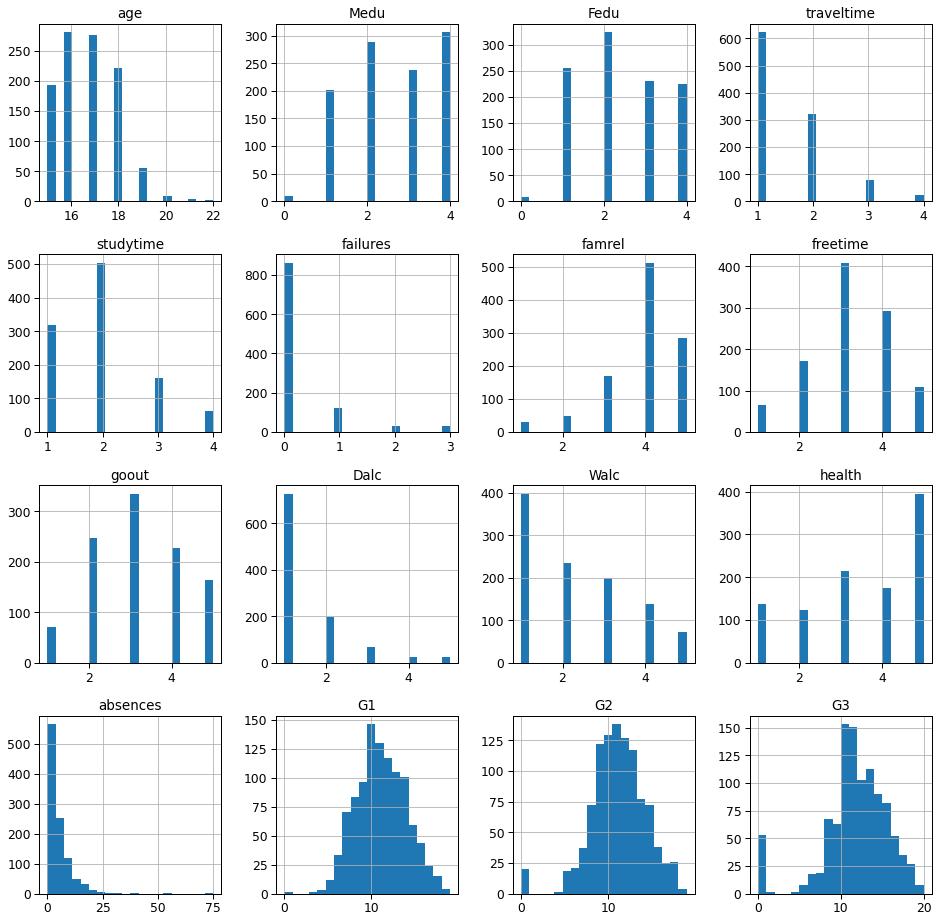

```python
data.hist(bins = 20, figsize=(16, 16))
plt.show()
```

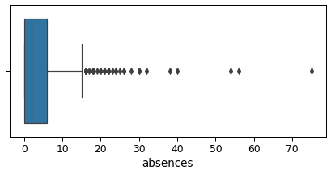

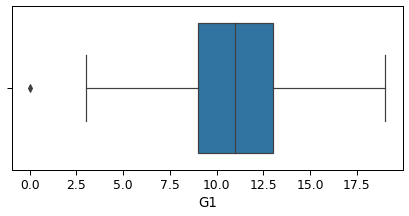

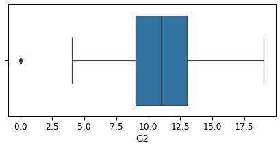

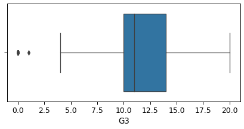

```python
# Jedynie dla zmiennych o rozkładzie ciągłym
for col in data.loc[:,["absences", "G1", "G2", "G3"]].columns:
    plt.figure(figsize=(7,3))
    sns.boxplot(data=data, x = col)
    plt.show()
```

Widać tutaj rzecz, o której wcześniej zostało napisane, a mianowicie, że z powyższych zmiennych ilościowych jedynie cztery z nich (absences, G1, G2, G3) mają rozkład ciąły, natomiast reszta dyskretny.

Naszą zmienną celu jest G3, jednakże wartości w kolumnach G1 oraz G2 są z nią mocno powiązane. Z tego też względu przyjżymy się dokladniej histogramom zmiennych w większej skali.

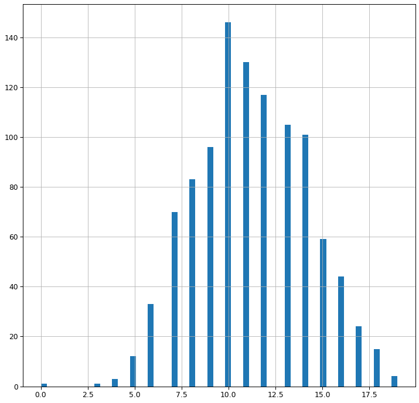

```python
data["G1"].hist(bins = 60)
plt.show()
```

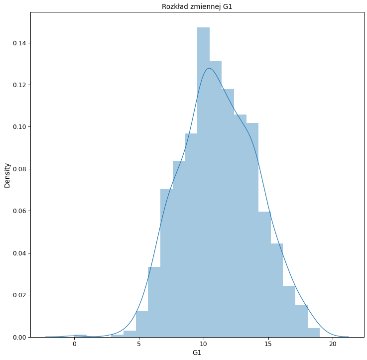

```python
dis_dist = sns.distplot(data['G1'], bins = 20)
dis_dist.set_title('Rozkład zmiennej G1')
plt.show()
```

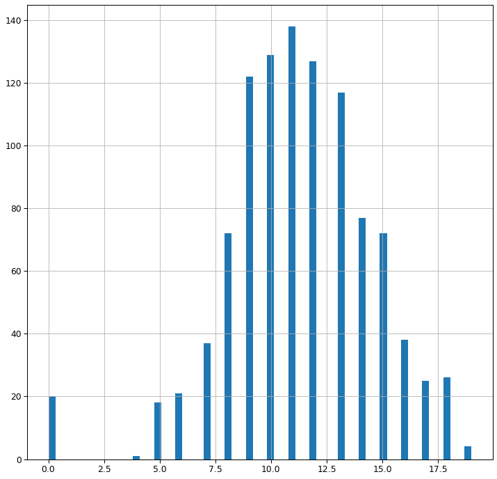

```python
data["G2"].hist(bins = 60)
plt.show()
```

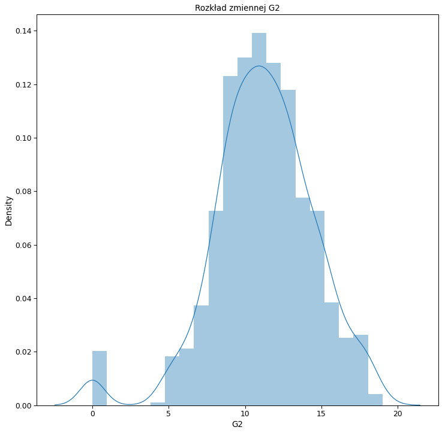

```python
dis_dist = sns.distplot(data['G2'], bins = 20)
dis_dist.set_title('Rozkład zmiennej G2')
plt.show()
```

## Zmienna celu - G3 (końcowa ocena ucznia)

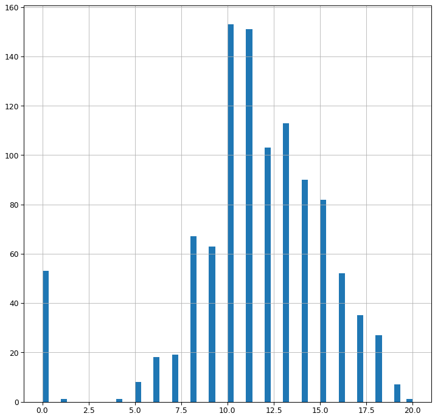

```python
# Zmienna celu
data["G3"].hist(bins = 60)
plt.show()
```

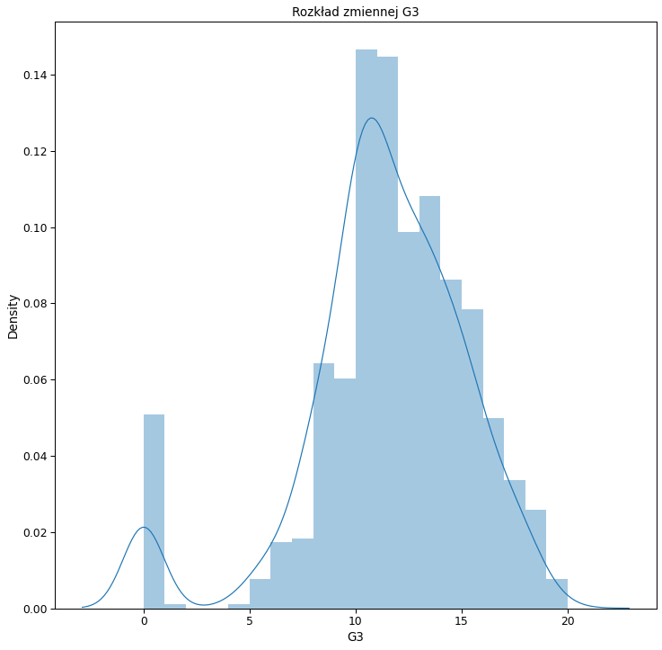

```python
dis_dist = sns.distplot(data['G3'], bins = 20)
dis_dist.set_title('Rozkład zmiennej G3')
plt.show()
```

Można tutaj zauważyć, że zmianna G3 oprócz wartości zero ma dość ładny rozkład (podobny do normalnego). Skok dla wartości 0 może wynikać z tego, że jesli dany uczeń ma już niskie oceny, w poprzednich etapach nauki (zmienna G1 oraz G2), to nie kończy szkoły. Z tego właśnie może wynikać ocena 0 na koniec. Są to jednakże dopiero pewne przypuszczenia poparte jedynie intuicją, które mogą zostać później zweryfikowane.

### Rozkłady zmiennych jakościowych

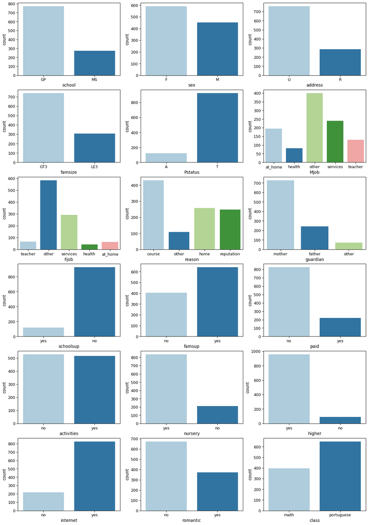

```python
discrete_col_names = data.select_dtypes(include = 'object').columns
fig, axes = plt.subplots(6,3, figsize = (20, 30))
sns.set_palette("Paired")

for col, ax in zip(discrete_col_names, axes.flatten()):
    sns.countplot(x=col, data=data, ax=ax)
```

## Heat map, czyli zależności między zmiennymi

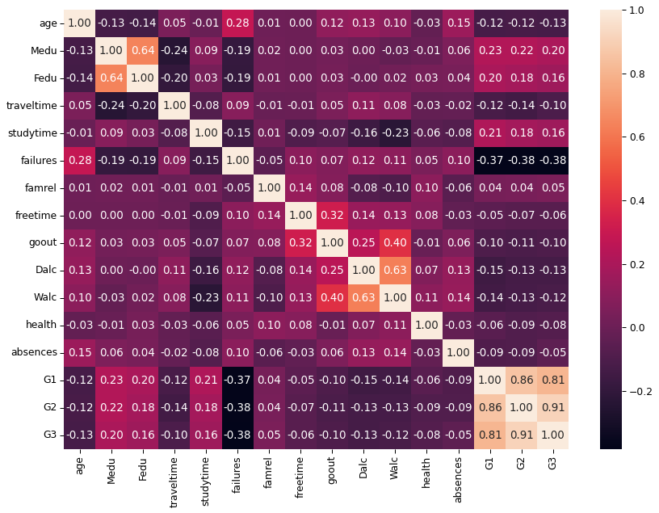

```python
plt.figure(figsize=(14,10))
corr = data.corr()
sns.heatmap(corr, xticklabels=corr.columns.values, yticklabels=corr.columns.values, annot=True, fmt=".2f")
```

Spoglądając na powyższy wykres, widać że największą korelację (co do modułu) ze zmiennymi G1, G2, G3 ma zmienna failures. Okazuje się, że zmienne Dalc i Walc, określające zpożycie alkoholu, nie mają większego wpływu. Może to nie zawsze zgadzać się z intuicją, więc przyjrzymy się temu z bliska, aby zauważyć, że intuicja choć istotna, bywa zawodna.

Dodatkowo spojrzymy jak dokładnie wygląda korelacja między G1 a G3, G2 a G3 oraz goout a Walc.

### Rozkład ocen dla różnego spożycia alkoholu w weekendy przez uczniów

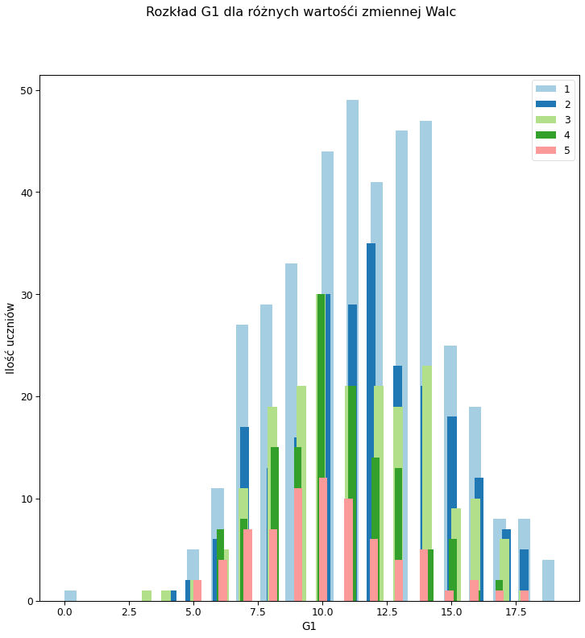

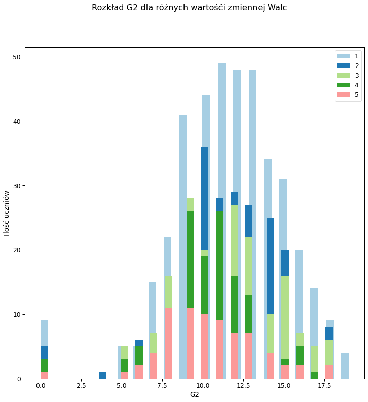

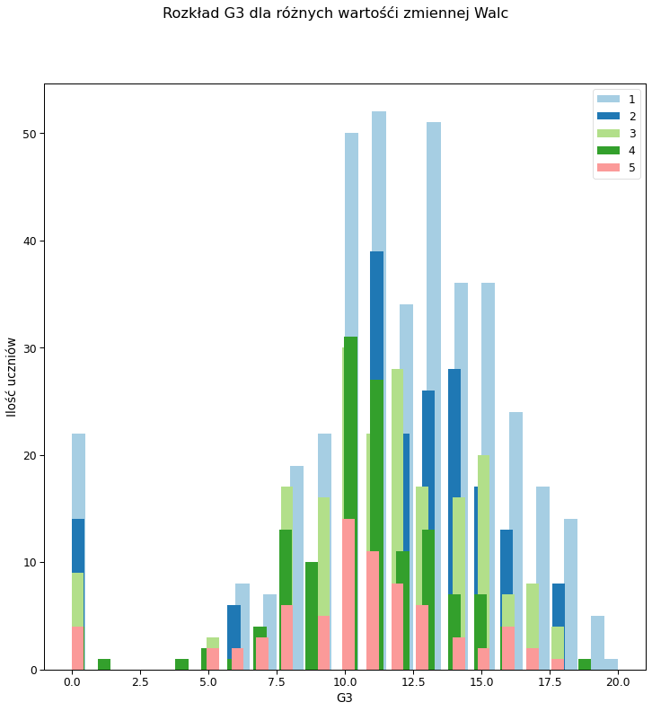

```python
sns.set_palette("Paired")
col_names = ["G1", "G2", "G3"]
table = [(1),(2),(3),(4),(5)]
bins = 40
alpha = 1

for col in col_names:
    fig, ax = plt.subplots()

    for num in table:
        ax.hist(data[data["Walc"]==num][col], bins=bins, alpha=alpha, label=num)

    ax.set_xlabel(col)
    ax.set_ylabel("Ilość uczniów")

    fig.suptitle(f"Rozkład {col} dla różnych wartośći zmiennej Walc")

    ax.legend()
    plt.show()
```

De facto nie można wyciągnąć żadnych konkretnych wniosków na temat rozkładu ocen końcowych na każdym etapie edukacji w zależności od ilości spożywanego alkoholu w weekend. Występują pewne drobne różnice, ale nie są one na tyle znaczące, aby mów wyciągnąc dalekoidące wnioski.

### Rozkład ocen dla różnego spożycia alkoholu w tygodniu przez uczniów

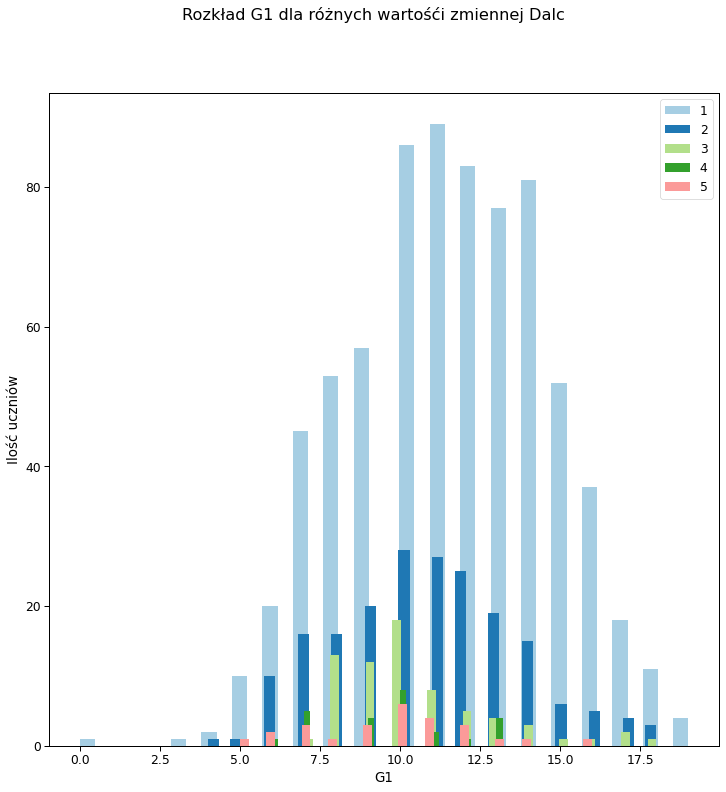

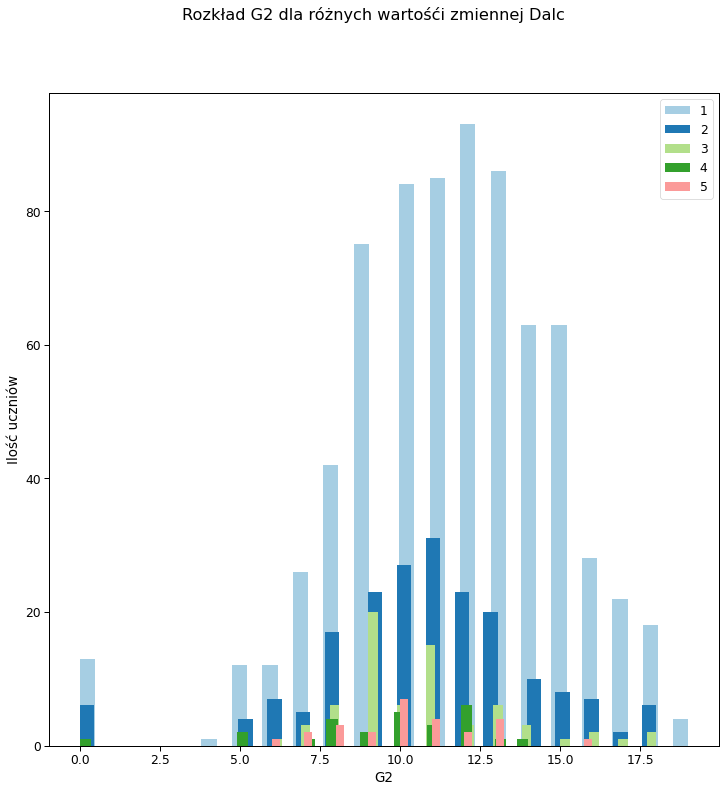

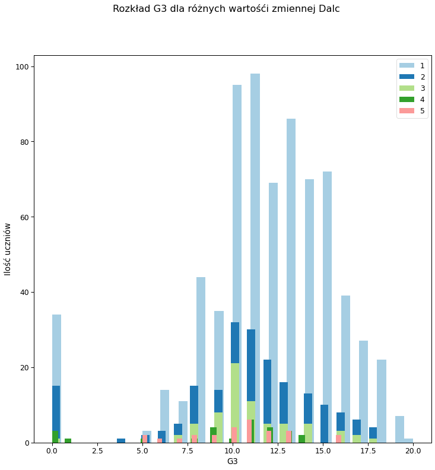

```python
sns.set_palette("Paired")
col_names = ["G1", "G2", "G3"]
table = [(1),(2),(3),(4),(5)]

bins = 40
alpha = 1

for col in col_names:
    fig, ax = plt.subplots()

    for num in table:
        ax.hist(data[data["Dalc"]==num][col], bins=bins, alpha=alpha, label=num)

    ax.set_xlabel(col)
    ax.set_ylabel("Ilość uczniów")

    fig.suptitle(f"Rozkład {col} dla różnych wartośći zmiennej Dalc")

    ax.legend()
    plt.show()
```

Analiza wykresów rozkładu ocen w zależności od spożycia alkoholu w tygodniów nie wnosi niczego konkretnego do analizy zbioru danych.

### Rozkład ocen dla różnego liczby niezaliczonych lat nauki

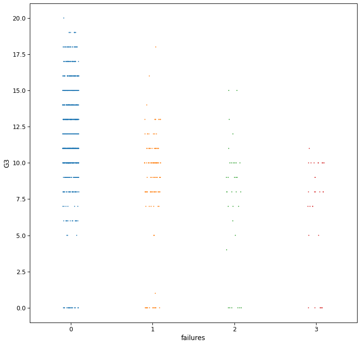

```python
sns.set_palette("tab10")
sns.stripplot(data = data, x = "failures", y = "G3", dodge = False, size = 2)
```

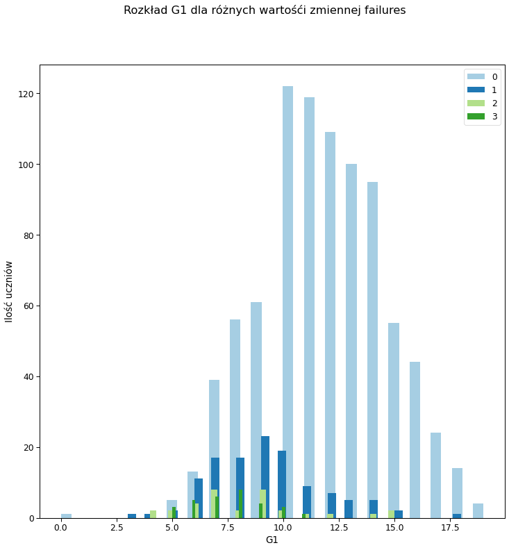

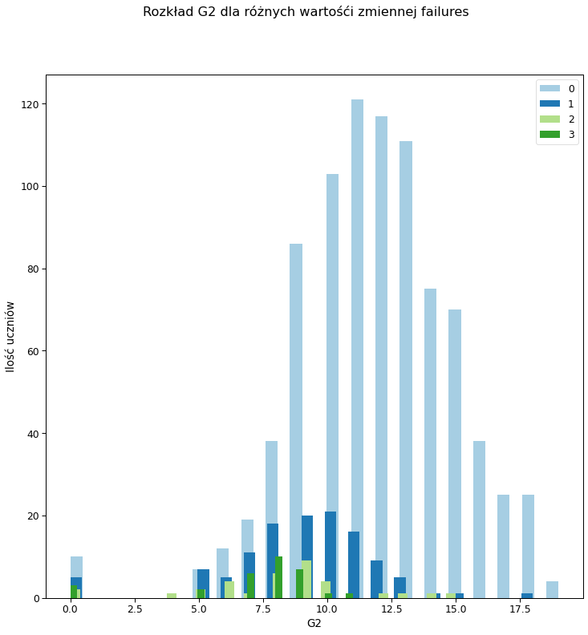

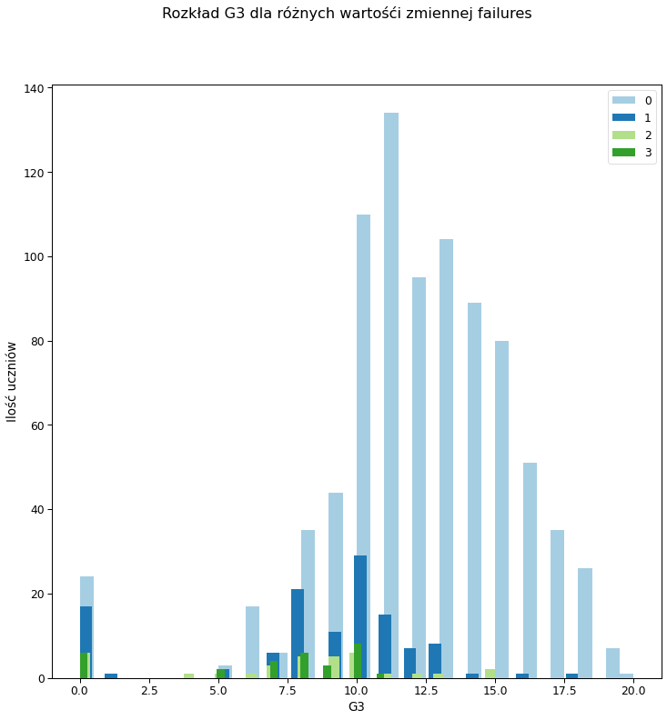

```python
sns.set_palette("Paired")
col_names = ["G1", "G2", "G3"]
table = [(0),(1),(2),(3)]
bins = 40
alpha = 1

for col in col_names:
    fig, ax = plt.subplots()

    for num in table:
        ax.hist(data[data["failures"]==num][col], bins=bins, alpha=alpha, label=num)

    ax.set_xlabel(col)
    ax.set_ylabel("Ilość uczniów")

    fig.suptitle(f"Rozkład {col} dla różnych wartośći zmiennej failures")

    ax.legend()
    plt.show()
```

#### Mediany ocen dla róznych wartości zmiennej failures

```python
data.loc[:, ["G1", "G2", "G3", "failures"]].groupby(["failures"]).aggregate(np.median)
```

| failures | G1 | G2 | G3 |
| --- | --- | --- | --- |
| 0 | 12.0 | 12.0 | 12.0 |
| 1 | 9.0 | 9.0 | 10.0 |
| 2 | 8.0 | 9.0 | 8.0 |
| 3 | 8.0 | 8.0 | 8.0 |

#### Średnie ocen dla róznych wartości zmiennej failures

```python
data.loc[:, ["G1", "G2", "G3", "failures"]].groupby(["failures"]).aggregate(np.mean)
```

| failures | G1 | G2 | G3 |
| --- | --- | --- | --- |
| 0 | 11.736353 | 11.829268 | 12.054588 |
| 1 | 9.175000 | 8.933333 | 8.425000 |
| 2 | 8.272727 | 8.121212 | 7.484848 |
| 3 | 7.600000 | 7.200000 | 6.800000 |

Spoglądając na wykresy oraz tabele można zauważyć, że oceny są niższe dla większej liczby niezaliczonych lat. Można przyrównać wnioski uzyskane z rozkładów z ujemną koralacją na poziomie około -0.38 zmiennej failures ze zmiennymi G1, G2 oraz G3

## Zalezność między ocenami

### Zalezność między G1 a G3

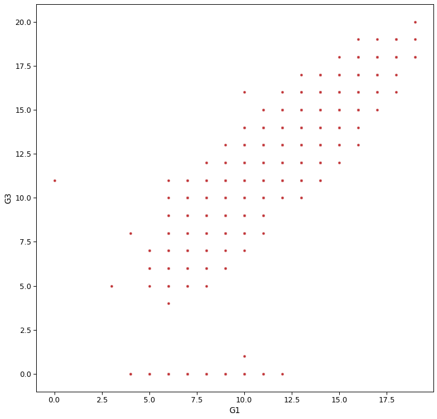

```python
sns.set_palette("RdBu")
sns.scatterplot(x="G1", y="G3", data=data)
```

### Zalezność między G2 a G3

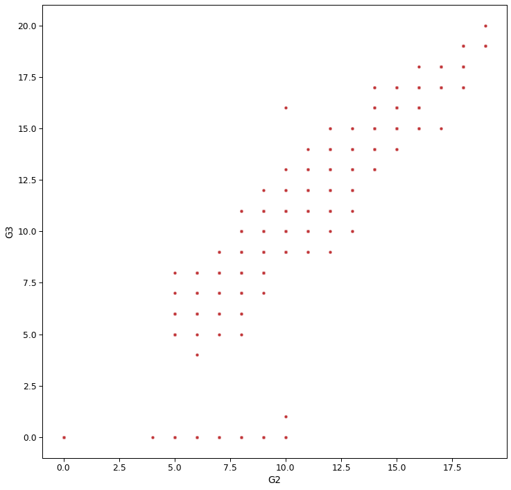

```python
sns.set_palette("RdBu")
sns.scatterplot(x="G2", y="G3", data=data)
```

Zależność między ocenami jest duża, co wynika z heat mapy i powyższych wykresów. Jedyną rzeczą która w pewnym sensie nie zapewni ładnej zależności między zmiennymi jest wzrost liczby osób z ocenami końcowymi równymi 0 dla zmiennej G3, gdzie te wzrosty dla zmiennych G1 oraz G2 były znacznie mniejsze.

## Zalezność między zmiennymi Walc a goout

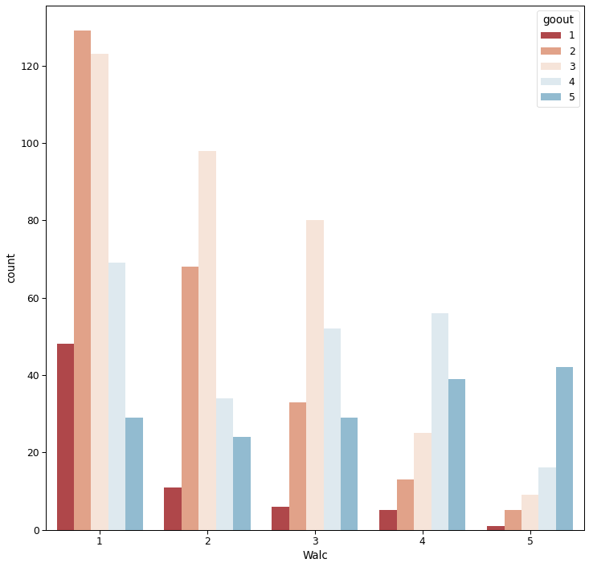

```python
sns.countplot(x="Walc",hue="goout", data=data)
```

Widać tutaj, że im wiecej wychodzisz ze znajomymi, tym więcej spożywasz alkoholu w weekendy i na odwrót. Zależność tę widać szczególnie dla wartości 4 i 5 zmiennej goout.

## Podsumowanie

Powyższa analiza z pewnością nie pokryła całego spektrum rzeczy, które można było zbadać. Jednakże zostały zbadane najważniesze zależności i zweryfikowane pewne intuicje (niekiedy błędne). W wyniku analizy danego zboru danych uzyskane zostały następujące wnioski:

- Oceny (zmienne G1, G2, G3) mają de facto rozkład bardzo zbliżony do normalnego. Wyjątkiem jest tutaj wyłącznie nagły wzrost dla wartości 0.
- Ilość zpożywanego alkoholu w tygodniu oraz w weekend nie wpływa w sposób zauważalny na oceny końcowe. Współczynnik korelacji mieści się w zakresie od -0.12 do -0.15. Tutaj intuicja zawodzi.
- Zmienna failures wpływa na spadek ocen końcowych. Dotyczy to spadku średniej, mediany oraz przesynięciu histogramu w kierunku ocen niższych.
- Występuje silna zależność między ocenami z poszczególnych etapów
- Korelacja miedzy czasem spędzonym ze znajomymi (zmienna goout) a ilością wypitego alkoholu w weekend (zmienna Walc).